# Concrete_Strength_Project6_AjitGaniger

### Multivariate Analysis

##### pair plot (between independent Variables)

```
Wall time: 7.66 s
```

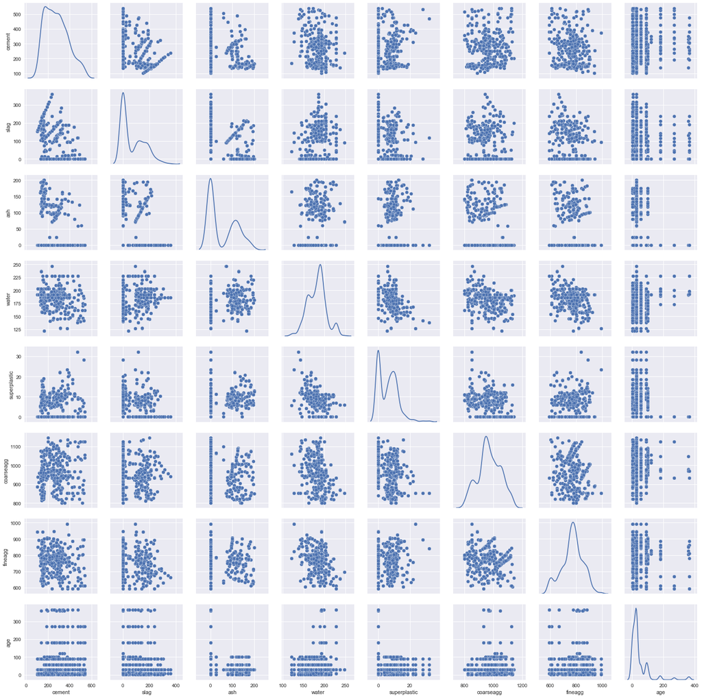

```python
%%time
sns.pairplot(data=data_df[features],diag_kind='kde')
```

> multivariate analysis
> - from the graph we see that data is spread like a cloud
> - we dont see much correlation between independent variable, which is good for building the model
> - we also notice that there could be 3 cluster at least , as we see in diagonal graph that there are multiple gaussians

##### pair plot (between independent and target variable)

```
Wall time: 876 ms
```

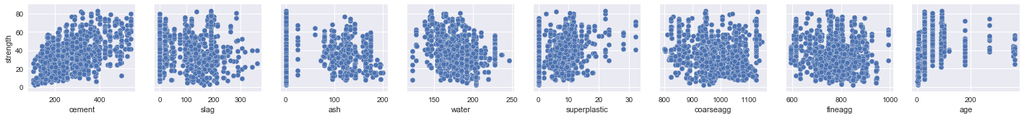

```python
%%time
sns.pairplot(x_vars=features,y_vars=target,data=data_df)
```

#### Lets plot heat-map to understand the correlation

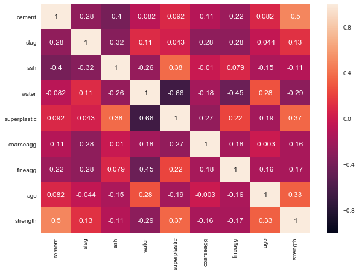

```python
plt.figure(figsize=(10,7))
corr = data_df.corr()
sns.heatmap(corr,annot=True,vmin=-1,vmax=1)
```

- There is no much correlation between independent variables, except between superplastic and water

### Data Preprocessing

- as part of our previous analysis we noticed that few features have zeros and some of them has outliers

```python
#Lets check zeros within each features

pd.DataFrame({'Zeros Count':(data_df[data_df[:]==0].count()),'Perc Zero':(data_df[data_df[:]==0].count()/data_df.count())*100})
```

|  | Perc Zero | Zeros Count |
| --- | --- | --- |
| cement | 0.000000 | 0 |
| slag | 45.728155 | 471 |
| ash | 54.951456 | 566 |
| water | 0.000000 | 0 |
| superplastic | 36.796117 | 379 |
| coarseagg | 0.000000 | 0 |
| fineagg | 0.000000 | 0 |
| age | 0.000000 | 0 |
| strength | 0.000000 | 0 |

- slag, ash and superplastic features have more than 36% zero values, This is major data with zero however domain knowledge would have given us more confidence , so lets keep them as it is

```python
# Lets copy original data
new_df = data_df.copy()
```

```python
# Taking care of zeros in the dataset

#new_df[['slag','ash','superplastic']]=new_df[['slag','ash','superplastic']].replace(0,np.NAN)

#new_df['slag'].fillna(new_df['slag'].median(),inplace=True)
#new_df['ash'].fillna(new_df['ash'].median(),inplace=True)
#new_df['superplastic'].fillna(new_df['superplastic'].median(),inplace=True)
```

- We also notice that there were outliers , however we are going ahead with them as it is

#### Standardize the data

```python
new_df[features].head(5)
```

|  | cement | slag | ash | water | superplastic | coarseagg | fineagg | age |
| --- | --- | --- | --- | --- | --- | --- | --- | --- |
| 0 | 141.3 | 212.0 | 0.0 | 203.5 | 0.0 | 971.8 | 748.5 | 28 |
| 1 | 168.9 | 42.2 | 124.3 | 158.3 | 10.8 | 1080.8 | 796.2 | 14 |
| 2 | 250.0 | 0.0 | 95.7 | 187.4 | 5.5 | 956.9 | 861.2 | 28 |
| 3 | 266.0 | 114.0 | 0.0 | 228.0 | 0.0 | 932.0 | 670.0 | 28 |
| 4 | 154.8 | 183.4 | 0.0 | 193.3 | 9.1 | 1047.4 | 696.7 | 28 |

```python
# Lets standardize the data
#new_df[features]=new_df[features].apply(zscore)
new_df=new_df.apply(zscore)
```

```python
new_df.head()
```

|  | cement | slag | ash | water | superplastic | coarseagg | fineagg | age | strength |
| --- | --- | --- | --- | --- | --- | --- | --- | --- | --- |
| 0 | -1.339017 | 1.601441 | -0.847144 | 1.027590 | -1.039143 | -0.014398 | -0.312970 | -0.279733 | -0.355018 |
| 1 | -1.074790 | -0.367541 | 1.096078 | -1.090116 | 0.769617 | 1.388141 | 0.282260 | -0.501465 | -0.737108 |
| 2 | -0.298384 | -0.856888 | 0.648965 | 0.273274 | -0.118015 | -0.206121 | 1.093371 | -0.279733 | -0.395144 |
| 3 | -0.145209 | 0.465044 | -0.847144 | 2.175461 | -1.039143 | -0.526517 | -1.292542 | -0.279733 | 0.600806 |
| 4 | -1.209776 | 1.269798 | -0.847144 | 0.549700 | 0.484905 | 0.958372 | -0.959363 | -0.279733 | -1.049727 |

```python
new_df.shape
```

```
(1030, 9)
```

### Feature Engineering techniques

```python
# Lets use the method to evaluate the model

def evaluateModel(model,name):
    print("######Evaluate the model %s ###########"%(name))
    print("Training Accuracy score : \t %s "%(model.score(x_train,y_train)))
    print("Test Accuracy score : \t %s "%(model.score(x_test,y_test)))
```

```python
#Lets create method to find out the feature importance

def feature_importance_graph(model,data):
    importances = model.feature_importances_
    indices = np.argsort(importances)[::-1][:15]
    a = data.columns[:]
    features= a.drop(target,1)
    plt.figure(1)
    plt.barh(range(len(indices)), importances[indices], color='b', align='center')
    plt.yticks(range(len(indices)), features[indices])
```

```python
#Lets create method to find out the feature importance

def feature_importance(model):
    print(pd.DataFrame(model.feature_importances_,columns=['Imp'],index=x_train.columns))
```